# Propensity score matching

## Estimation of difference between direct and indirect data

In this notebook, we present alternative analysis of our data, using technique, known as propensity score matching (Rosenbaum and Rubin 1983).

To compare target variables (i.e. `ITM` and `Russian`) between direct and indirect data, we have to take into account that chances to obtain observation in direct or indirect data depend on other variables of this observation (most notably, on `year_of_birth`). These variables can also affect the target variables (i.e. ITM decreases with time) and thus produce bias in our estimates (effect known as *confounding*). To adjust for this bias, in the main paper we compare predictions of machine learning models instead of comparing values of target variables directly. This is similar to adjustment procedure used in econometrics, where potential confounders are added into the regression models to “isolate” causal effect of the variable we are interested in (in our case, data type).

Propensity score matching is another approach to deal with this problem. This is two-step procedure. At the first step, we construct a predictive model that estimates probability for an observation to be included in the indirect subsample, based on the values of other variables. At the second step, we *match* every item in the direct data with some element in the indirect data in such a way that both items, according to values of other variables and our model, has the same probability to be included in the indirect data. This allows us to produce balanced dataset and then compare variables of interest directly.

We will use `MatchIt` library (Ho, Imai, King and Stuart 2011) to make the actual matching. Due to non-linear nature of our data, we use random forest algorithm to estimate the probability at the first step instead of the logistic regression (which is the default).

```r
library(tidyverse)
library(MatchIt)
library(patchwork)

ITM <- read.csv("data/ITM.csv")
russian <- read.csv("data/russian.csv")
```

### ITM

In propensity score matching, the variable which effect we estimate (i.e. `type` variable in our case) is called *treatment variable* and corresponding groups are called “treatment group” (i.e. treatment variable equals to 1) and “control group” (i.e. treatment variable equals to 0). It is usually assumed that control group is at least as large as treatment group (or larger). Thus we denote *indirect data* as control group and *direct data* as treatment group.

```r
# type == 1 means direct data, type == 0 otherwise
set.seed(1)
mod_match_ITM <- matchit(type ~ year_of_birth
                         + language.population
                         + elevation
                         + village.population
                         + mother.tongue
                         + residence
                         + sex,
                         method = "nearest",
                         distance = "randomforest",
                         data=ITM,
                         discard='both'
                         )
dta_m_ITM <- match.data(mod_match_ITM)
```

Now `dta_m_ITM` consists of matched samples. This is our approximation to the balanced dataset.

```r
t.test(number.of.lang ~ type, data = dta_m_ITM)
```

```
##
##  Welch Two Sample t-test
##
## data:  number.of.lang by type
## t = 1.5301, df = 2648.2, p-value = 0.1261
## alternative hypothesis: true difference in means is not equal to 0
## 95 percent confidence interval:
##  -0.01268308  0.10277317
## sample estimates:
## mean in group 0 mean in group 1
##       0.7965465       0.7515015
```

We see that the difference in ITM between direct and indirect data is statistically insignificant, that is in agreement with the results of our paper.

### Visualizations

Here we construct plots that shows the dependence of ITM in direct and indirect data for initial dataset and balanced dataset (after the matching).

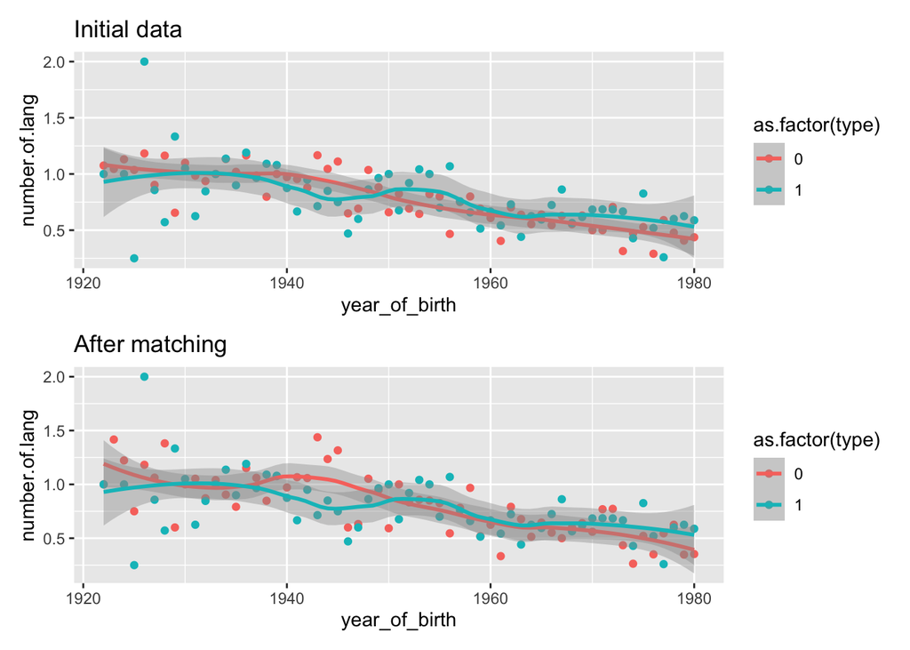

```r
dta_m_ITM %>%
  group_by(year_of_birth, type) %>%
  summarise_all(funs(mean)) %>%
  ggplot(aes(x=year_of_birth, y=number.of.lang, color=as.factor(type))) +
  geom_point() + geom_smooth(method='loess', span=0.5) + ggtitle("After matching")-> fig_m_ITM
ITM %>%
  group_by(year_of_birth, type) %>%
  summarise_all(funs(mean)) %>%
  ggplot(aes(x=year_of_birth, y=number.of.lang, color=as.factor(type))) +
  geom_point() + geom_smooth(method='loess', span=0.5) + ggtitle("Initial data") -> fig_ITM
fig_ITM / fig_m_ITM
```

### Russian

Here we repeat the same steps with `Russian` variable.

```r
mod_match_russian <- matchit(type ~ year_of_birth
                         + language.population
                         + elevation
                         + village.population
                         + mother.tongue
                         + residence
                         + sex,
              method = "nearest",
              distance = "randomforest",
              data = russian)
dta_m_russian <- match.data(mod_match_russian)
```

To estimate the difference, we will use bivariate logistic regression.

```r
fit <- glm(русский ~ type,
                  family=binomial(link='logit'),
                  data=dta_m_russian)
summary(fit)
```

```
##
## Call:
## glm(formula = русский ~ type, family = binomial(link = "logit"),
##     data = dta_m_russian)
##
## Deviance Residuals:
##     Min       1Q   Median       3Q      Max
## -2.0913   0.4881   0.4881   0.5876   0.5876
##
## Coefficients:
##             Estimate Std. Error z value Pr(>|z|)
## (Intercept)  1.66888    0.07541  22.131  < 2e-16 ***
## type         0.39867    0.11531   3.457 0.000546 ***
## ---
## Signif. codes:  0 '***' 0.001 '**' 0.01 '*' 0.05 '.' 0.1 ' ' 1
##
## (Dispersion parameter for binomial family taken to be 1)
##
##     Null deviance: 2090.8  on 2635  degrees of freedom
## Residual deviance: 2078.7  on 2634  degrees of freedom
## AIC: 2082.7
##
## Number of Fisher Scoring iterations: 4
```

We see that `type` is significant and type == 1 (direct data) gives larger value of Russian than type == 0 (indirect data). This is in agreement with the result in the paper and the coefficient is close to the value 0.4 reported in the paper (the sign is opposite as we are denoting systematic bias as “indirect data minus direct data”)

### Visualizations

[figure not shown]

```r
russian %>%
  group_by(year_of_birth, type) %>%
  summarise_all(funs(mean)) %>%
  ggplot(aes(x=year_of_birth, y=русский, color=as.factor(type))) +
  geom_point() + geom_smooth(method='loess', span=0.5) + ggtitle("After matching")-> fig_russian
dta_m_russian %>%
  group_by(year_of_birth, type) %>%
  summarise_all(funs(mean)) %>%
  ggplot(aes(x=year_of_birth, y=русский, color=as.factor(type))) +
  geom_point() + geom_smooth(method='loess', span=0.5) + ggtitle("Initial data")-> fig_m_russian

fig_russian / fig_m_russian
```

## Conclusions

The results of analysis based on propensity score matching is in agreement with results that is based on comparing predictions between two machine learning models.